## **Dibbler**

### Blamed on foxes

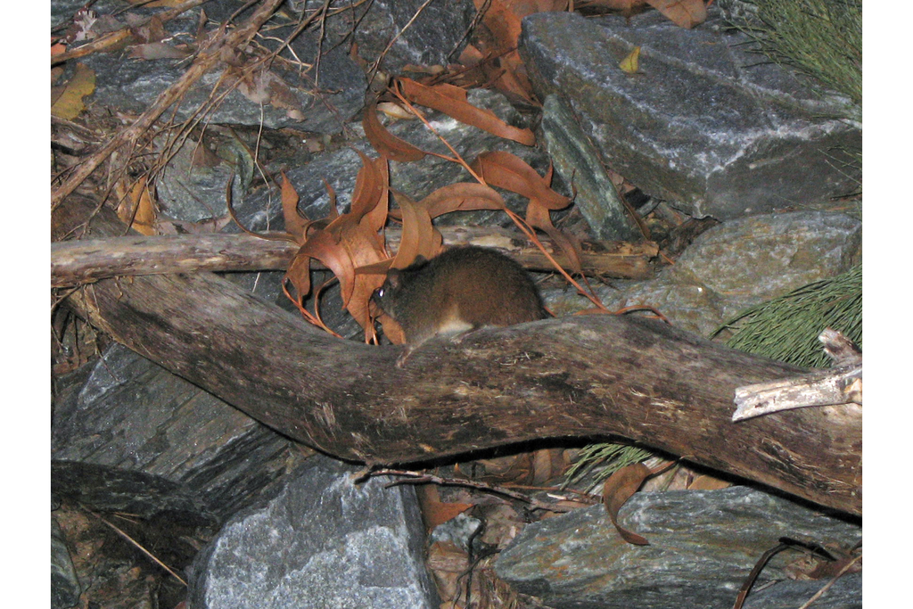

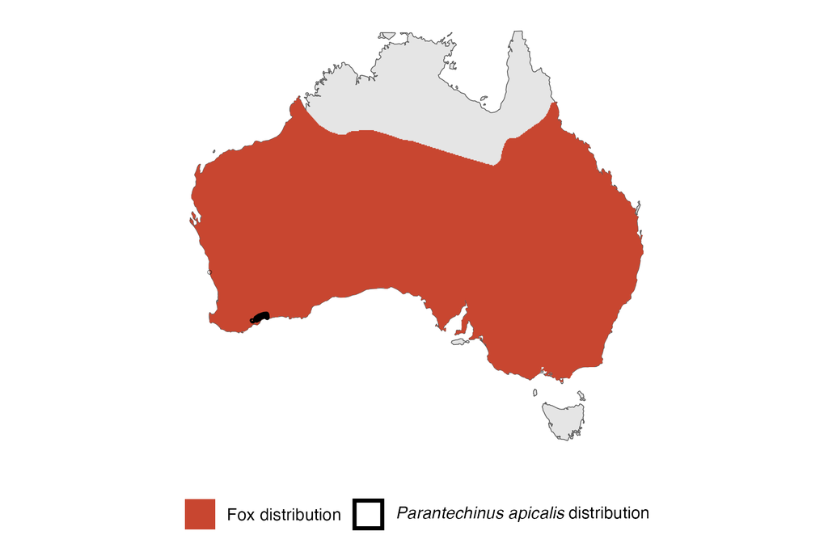

IUCN status: **Endangered**

EPBC Predator Threat Rating: **High**

IUCN claim: *“Introduced foxes and cats are known to prey on this species”*

### Studies in support

Foxes hunt dibblers (Friend 2003). Friend (2003) also stated that dibbler decline coincides with fox establishment but no data was provided. Dibblers were detected after several years of an intensive poison-baiting campaign (Kinnear et al. 2002, Friend 2003).

### Studies not in support

No studies

### Is the threat claim evidence-based?

No studies were found evidencing a negative association between foxes and dibbler populations that analyse data.

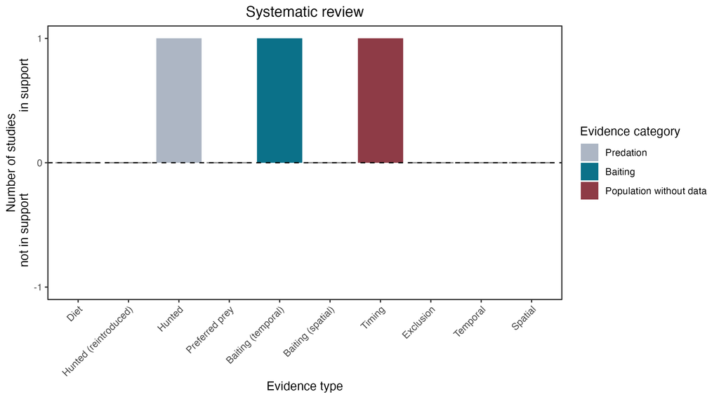

**Evidence linking *Parantechinus apicalis* to foxes.** Systematic review of evidence for an association between *Parantechinus apicalis* and foxes. Positive studies are in support of the hypothesis that *foxes* contribute to the decline of Parantechinus apicalis, negative studies are not in support. Predation studies include studies documenting hunting or scavenging; baiting studies are associations between poison baiting and threatened mammal abundance where information on predator abundance is not provided; population studies are associations between threatened mammal and predator abundance. Gold borders indicate studies that meet qualities of scientific rigour. See methods section in Wallach and Lundgren 2025 for details on evidence categories.

### References

EPBC. (2015) Threat Abatement Plan for Predation by Feral Cats. Environment Protection and Biodiversity Conservation Act 1999, Department of Environment, Government of Australia. (Table A1).

Friend T. 2003. Dibbler (Parantechinus apicalis) Recovery Plan July 2003–June 2013. Wildlife Management Program. Department of Conservation and Land Management Western Australian Threatened Species and Communities Unit

IUCN Red List. https://www.iucnredlist.org/ Accessed June 2023

Kinnear, J.E., Sumner, N.R. and Onus, M.L., 2002. The red fox in Australia—an exotic predator turned biocontrol agent. Biological Conservation, 108(3), pp.335-359.

Wallach A.D., Lundgren E.J. (2025) Review of evidence that foxes and cats cause extinctions of Australia’s endemic mammals. BioScience. DOI: 10.1093/biosci/biaf046